# Homework #3

Gajin Kim

9/23/2021

To load dataset,

```r
library(classdata)
library(dplyr)
data(ames)
```

Include at least one `ggplot` visualization in each of your answer except for Question 2, and describe what you find.

1. Explore and explain what is the relationship between the sale price (y) and living area size (x). In your visualization, add a straight line with intercept at 20000 and slope equal to 100. Look at `?geom_abline`, and in particular the examples. Remark on any patterns you find and the straight line.

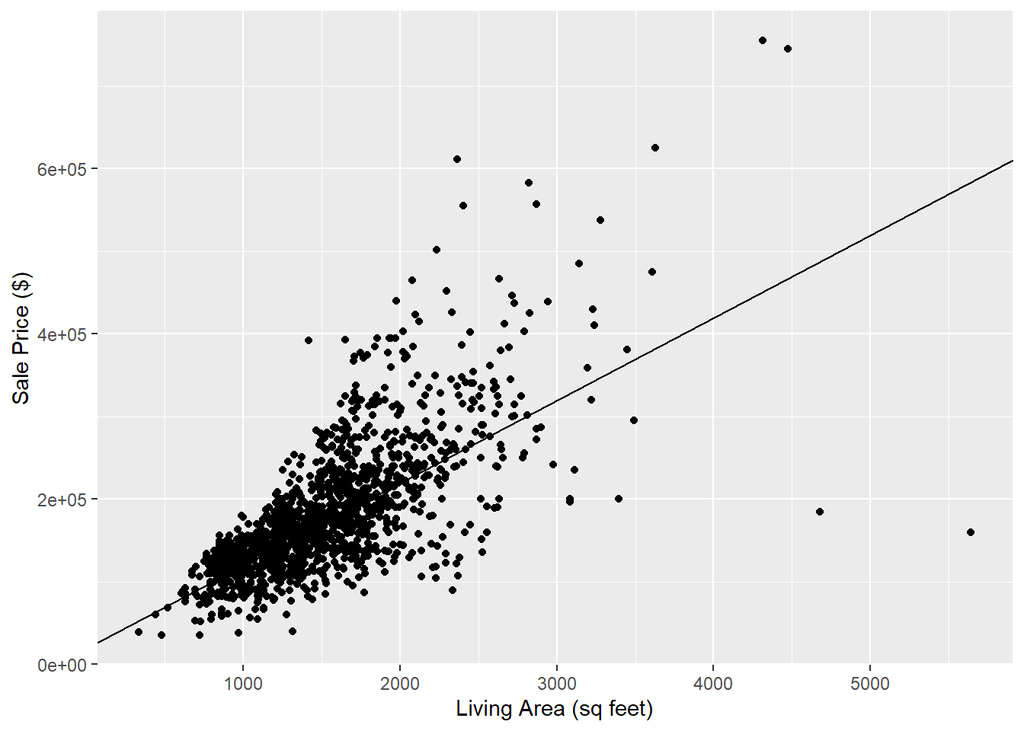

[output not shown]

```r
library(ggplot2)
ggplot(data = ames, aes(x = GrLivArea, y = SalePrice)) + xlab("Living Area (sq feet)") + ylab("Sale Price ($)") + geom_point() + geom_abline(intercept = 20000, slope = 100)
```

2. Describe at least two types of anomalies in the previous plot. What do they mean?

```r
# Question 2 does not require a ggplot visualization (stated above).
```

[output not shown]

[output not shown]

3. Visualize the number of sales by the overall condition. Make sure the conditions are ordered from the best to the worst. What do you find?

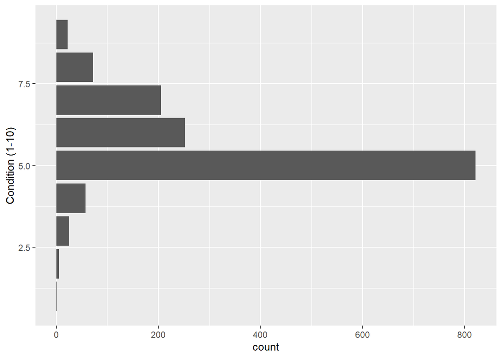

```r
ggplot(data = ames, aes(x = OverallCond)) + xlab("Condition (1-10)") + geom_bar() + coord_flip()
```

```r
summary(ames$OverallCond)
```

```
##    Min. 1st Qu.  Median    Mean 3rd Qu.    Max.
##   1.000   5.000   5.000   5.575   6.000   9.000
```

```r
# ames %>% count(OverallQual)
```

[output not shown]

4. Introduce a variable `houseAge` into the data set which stands for the age of the house at the time when it was sold. How does the age of the house affect the sale price?

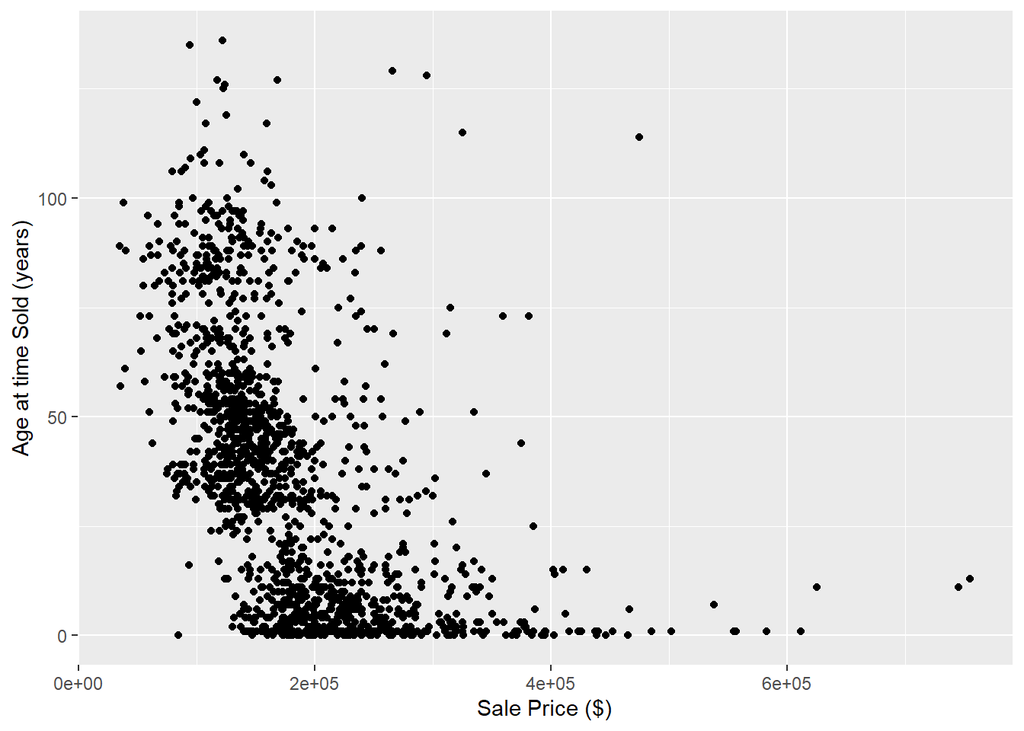

```
There is a slight inverse (possibly exponential) relationship between house age and sale price. As we can loosely observe from the graph, the older the house, the less it tends to sell for.

Also, there seems to be a gap in the number of houses sold at ~25 years. This could possibly imply that most houses that are ~25 years of age are off the market due to various reasons, such as being occupied.
```

```r
ames$houseAge <- ames$YrSold - ames$YearBuilt
ggplot(data = ames, aes(x = houseAge, y = SalePrice)) + xlab("Age at time Sold (years)") + ylab("Sale Price ($)") + geom_point() + coord_flip()
```

5. Were there more sales of nice houses or poor houses? Make sure to state your criterion for a house to be “nice” or otherwise “poor”. Choose an appropriate graph type.

```
nice criteria:
* YearBuilt > 1971 (mean: 1971) #summary(ames$YearBuilt)
* Living Area > 1515 sq ft (mean: 1515) #summary(ames$GrLivArea)
* Overall Condition: 6+

poor criteria:
* YearBuilt < 1971 (mean: 1971)
* Living Area < 1515 sq ft (mean: 1515)
* Overall Condition: 4-
```

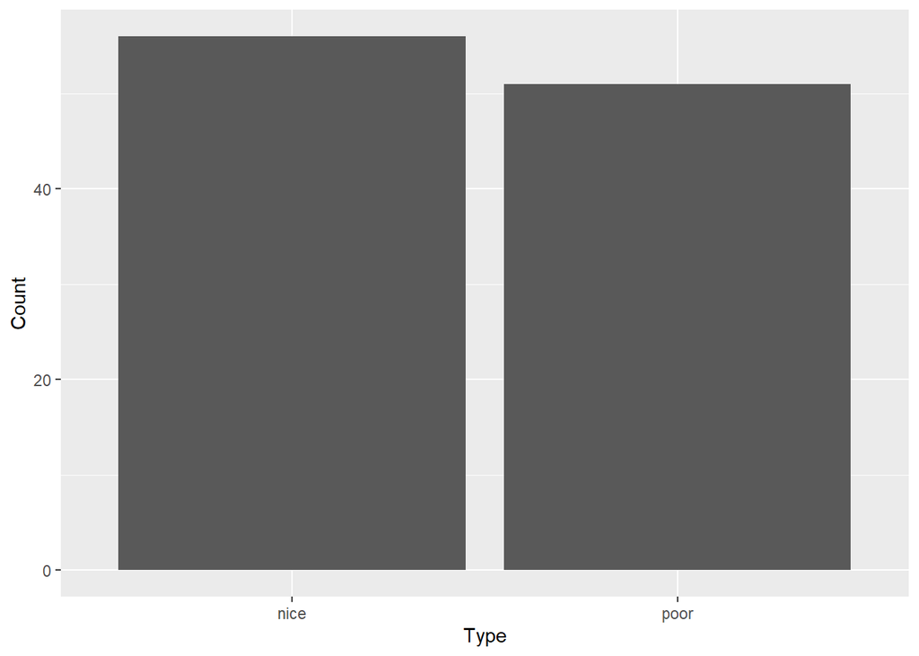

```
Based on my chosen criteria, the number of nice houses sold exceeded that of poor houses by 5. However, based on the number of total houses sold, a 5 house difference is not significant enough to come to any real conclusions.
```

```r
nice <- nrow(subset(ames, YearBuilt > 1971 & GrLivArea > 1515 & OverallCond >= 6)) # 56
poor <- nrow(subset(ames, YearBuilt < 1971 & GrLivArea < 1515 & OverallCond <= 4)) # 51
NicePoor <- data.frame(Type = c("nice", "poor"), Count = c(nice, poor)) # new dataframe

ggplot(NicePoor, aes(x = Type, y = Count)) + geom_col()
```

6. How do the neighborhood and the slope of property affect the relationship between sale price and year built? Focus on the neighborhoods of Brookside, Clear Creek, College Creek, and Somerset only. Find a visualization that incorporates all four variables. Interpret the result.

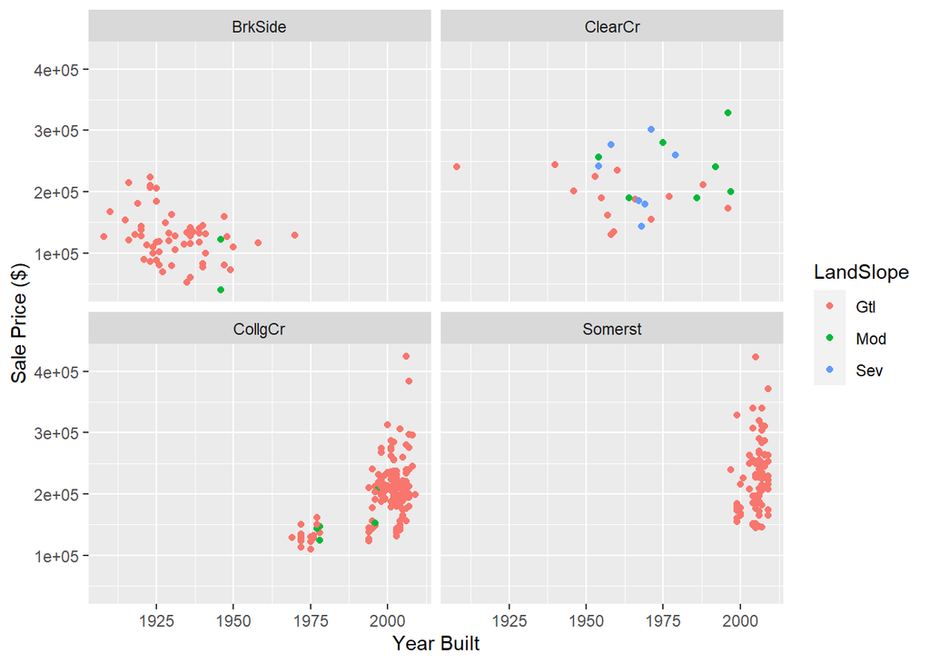

```
Amongst the four selected neighborhoods, Somerset only consists of gentle slopes, Brookside and College Creek mostly have gentle and a few moderate slopes, and Clear Creek has a fairly even distribution of gentle, moderate, and severe slopes.

Brookside tends to have older houses, Clear creek has a fairly even distribution of old and new houses, and College Creek and Somerset have mostly newer houses.

Brookside tends to have cheaper houses compared to Clear Creek, College Creek, and Somerset.

Overall, it seems that neighborhood has a greater impact than landslope when it comes to predicting the sale price and year built. This makes sense because when new neighborhoods are constructed, a lot of their houess are built and sold around the same time.
```

```r
# slope types: "Gtl" "Mod" "Sev # unique(ames$LandSlope)
# neighborhoods: "BrkSide" "ClearCr" "CollgCr" "Somerst"

FocusNeighborhoods <-  ames[ames$Neighborhood %in% c('BrkSide', 'ClearCr', 'CollgCr', 'Somerst'), ]

ggplot(FocusNeighborhoods, aes(x=YearBuilt, y=SalePrice, color=LandSlope)) + xlab("Year Built") + ylab("Sale Price ($)") + geom_point() + facet_wrap(~Neighborhood)
```

7. Create a side-by-side histogram showing the sales price for the different types of buildings. Comment on the result.

```r
unique(ames$BldgType) # "1Fam" "2fmCon" "Duplex" "TwnhsE" "Twnhs"
```

```
## [1] "1Fam"   "2fmCon" "Duplex" "TwnhsE" "Twnhs"
```

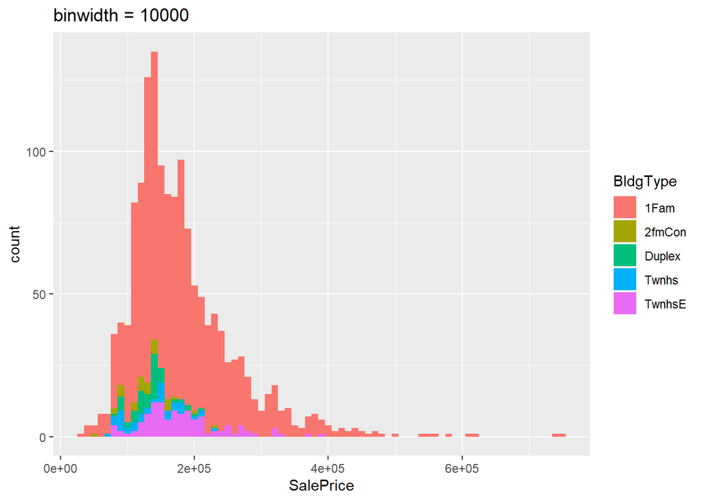

```
Based on the side-by-side histogram we can observe that all building types generally settle around the $100,000 to $250,000 range.

The building type that has the greatest values is 1 Family, followed by TwnhsE. 2 family condos, duplexes, and town hs are all heavily concentrated in the same area.

Furthermore, the sale prices of 1 family buildings have the greatest distrbution of all building types.
```

```r
BuildingTypes <-  ames[ames$BldgType %in% c('1Fam', '2fmCon', 'Duplex', 'TwnhsE', 'Twnhs'), ]

bw <- 10000
ggplot(BuildingTypes, aes(x = SalePrice, fill=BldgType)) + geom_histogram(binwidth=bw) + ggtitle(paste0("binwidth = ", bw))
```